# Introduction to `ggplot2`

## Scatter plots

A basic scatter plot requires only two quantitative variables

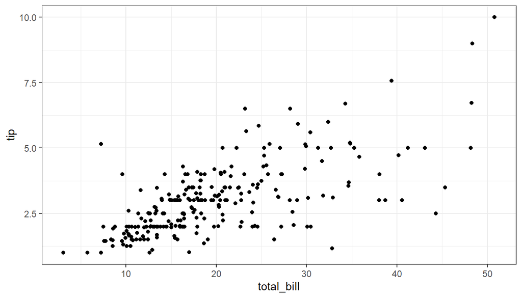

```r
ggplot(tips, aes(total_bill, tip)) + geom_point()
```

We can add color to this plot to represent a third variable: note that categorical variables will create a collection of “discrete” colors, while adding a quantitative variable will give us color on a scale

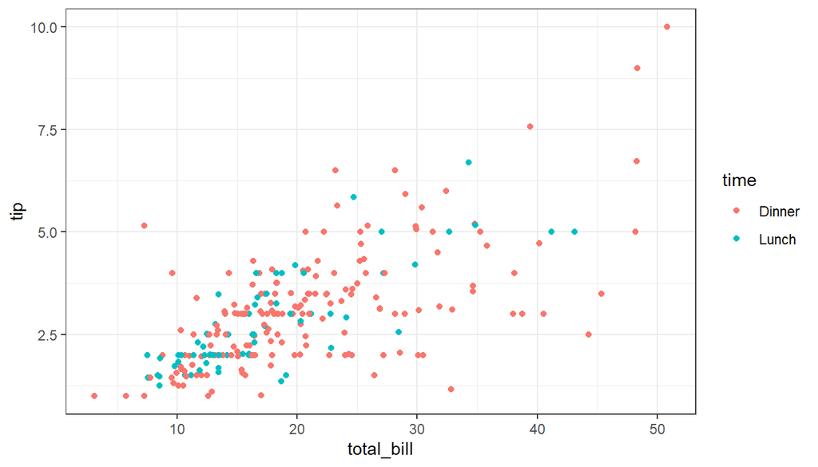

```r
# Categorical variable added
ggplot(tips, aes(total_bill, tip, color = time)) + geom_point()
```

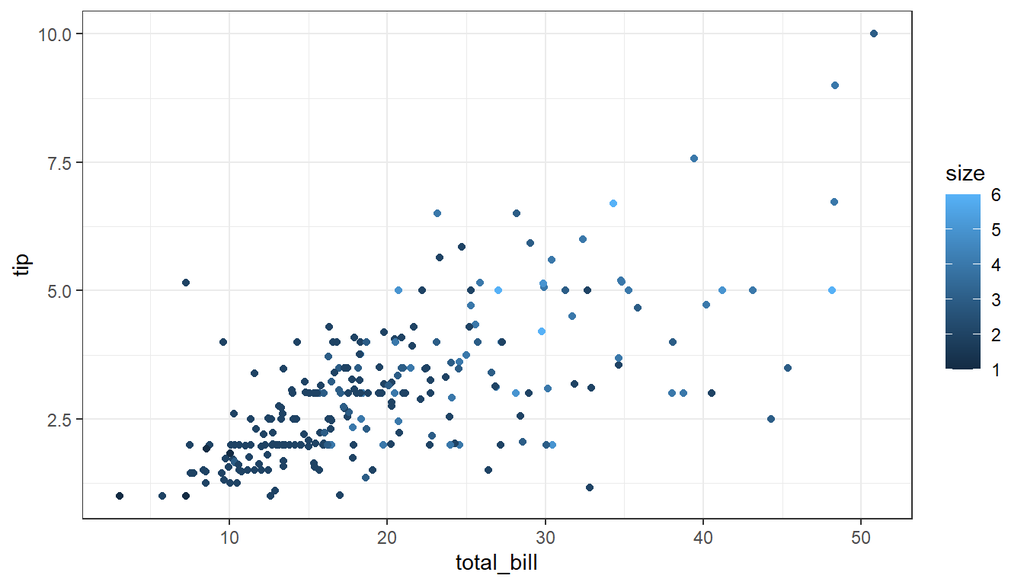

```r
# Quantitative variable added
ggplot(tips, aes(total_bill, tip, color = size)) + geom_point()
```

## Bar plots

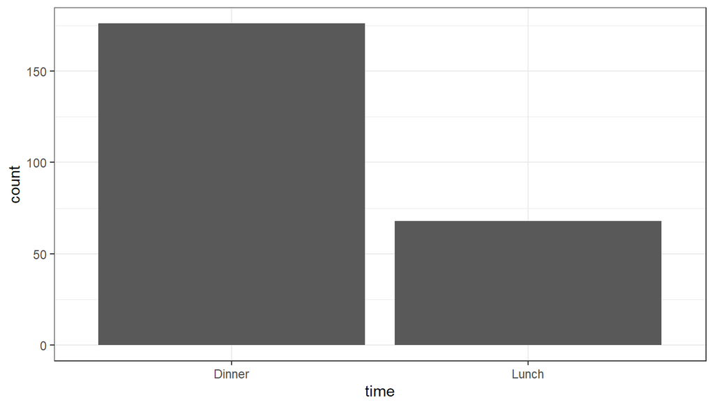

```r
ggplot(tips, aes(time)) + geom_bar()
```

#### Stacked

When adding additional categorical variables, the default behavior is to give a stacked bar chart

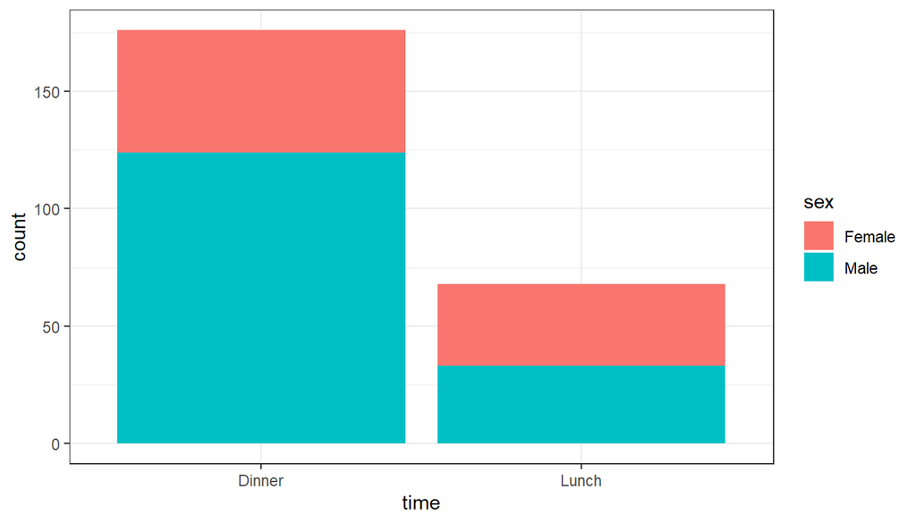

```r
ggplot(tips, aes(time, fill = sex)) + geom_bar()
```

Note that for bar charts our second aesthetic will almost always be `fill =`. This tells ggplot to “fill in” with the color of the group. Try doing `color = Sex` to compare

#### Dodge

We can change to a dodged bar chart by passing an argument to `geom_bar()`

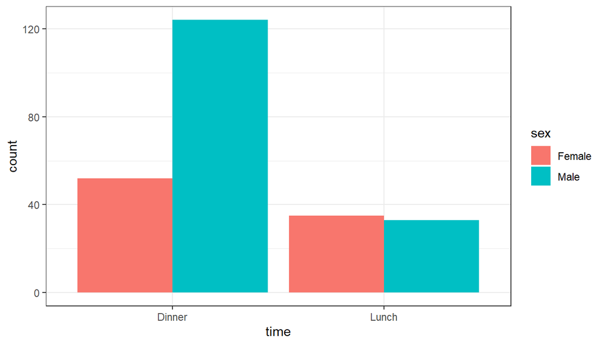

```r
ggplot(tips, aes(time, fill = sex)) + geom_bar(position = "dodge")
```

If there is a case in which one group has zero observations from another group, the default behavior for dodge looks weird. Here’s an example from the `mpg` dataset:

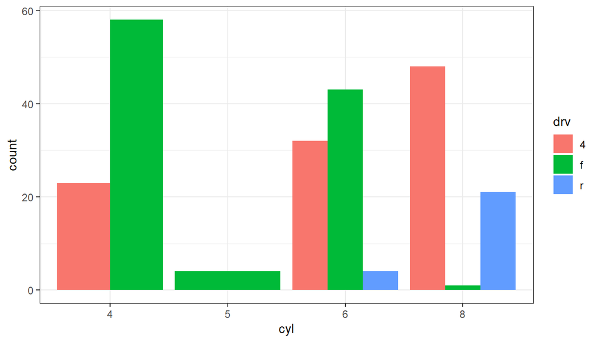

```r
ggplot(mpg, aes(cyl, fill = drv)) + geom_bar(position = "dodge")
```

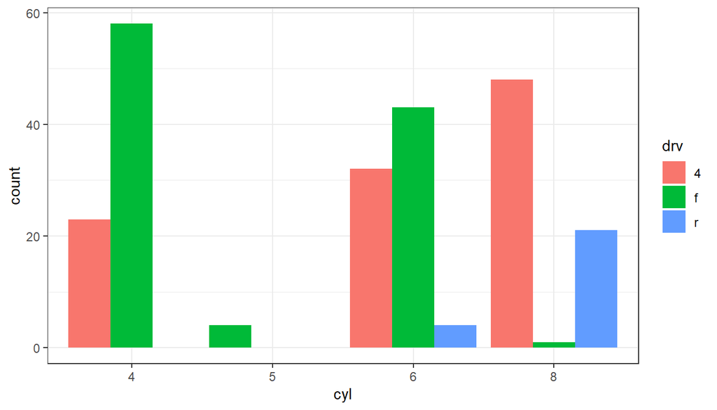

```r
ggplot(mpg, aes(cyl, fill = drv)) + geom_bar(position = position_dodge(preserve = "single"))
```

#### Filled charts (conditional)

Finally, we can get the filled/conditional charts by using `position = "fill"`

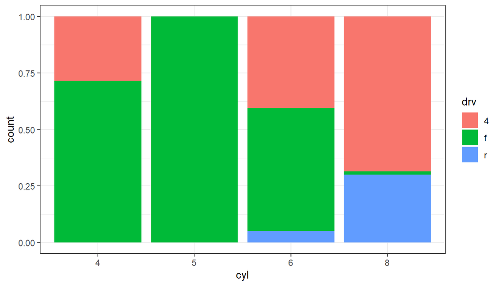

```r
ggplot(mpg, aes(cyl, fill = drv)) + geom_bar(position = "fill")
```

## Faceting

“Facetting” is a process whereby we split our plots up by a group or categorical variable, allowing us to see two (or more) side-by-side plots. This can be a handy way to view the relationship between two variables separately, conditioned on a third

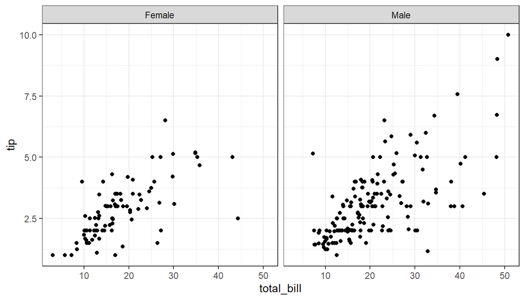

```r
ggplot(tips, aes(total_bill, tip)) +
  geom_point() +
  facet_wrap(~sex)
```

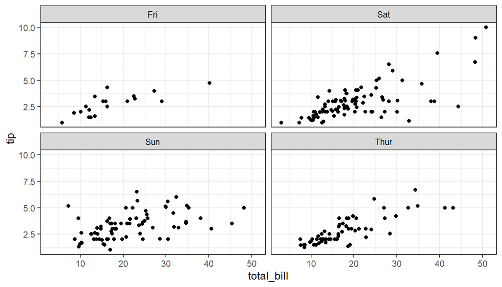

```r
ggplot(tips, aes(total_bill, tip)) +
  geom_point() +
  facet_wrap(~day)
```

The syntax is `facet_wrap(~var_name)` and can be added with `+` at the end of the plot

## Extra Details

Here are some extra examples for things you may be intereseted in modifying in your plot

### Labels and title

We can add labels and a title with the `labs()` function (short for labels). The arguments to change labels are shown below

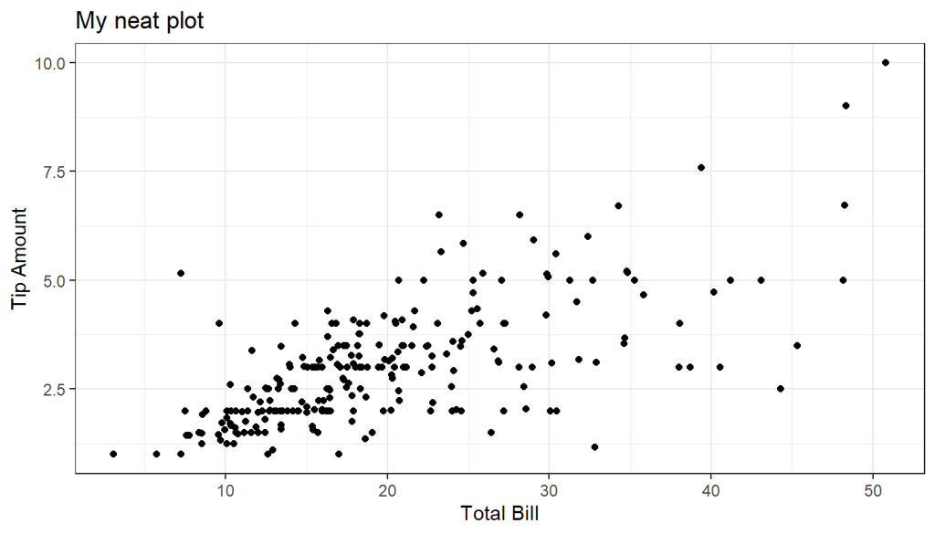

```r
ggplot(tips, aes(total_bill, tip)) +
  geom_point() +
  labs(x = "Total Bill", y = "Tip Amount", title = "My neat plot")
```

### Colors

This is (mostly) just for fun. If we use either a color or fill aesthetic in our plots, we can change the colors

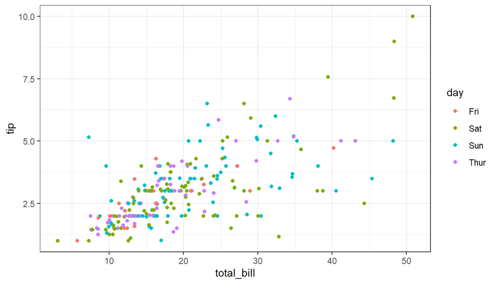

```r
# Original
ggplot(tips, aes(total_bill, tip, color = day)) +
  geom_point()
```

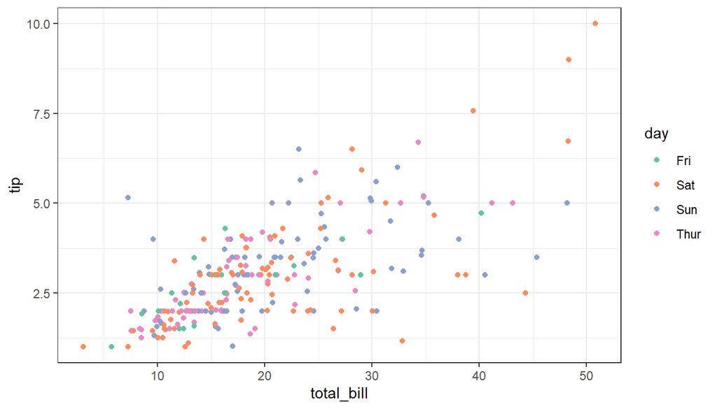

```r
# Using scale_color_brewer
ggplot(tips, aes(total_bill, tip, color = day)) +
  geom_point() +
  scale_color_brewer(palette = "Set2")
```

The syntax is nearly identical for fill using `scale_fill_brewer()`

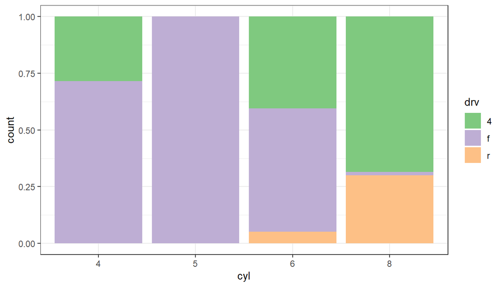

```r
ggplot(mpg, aes(cyl, fill = drv)) +
  geom_bar(position = "fill") +
  scale_fill_brewer(palette = "Accent")
```

A list of additional palettes can be found with `?scale_fill_brewer()` or `?scale_fill_color()`